# Common Trends Between Nintendo Platforms

Steven Hernandez

2023-03-30

Nintendo’s intellectual properties (IP) have allowed the company to became a household name.

- People from multiple generations recognize *Mario* or *Pokemon*.

However, the company had under-performing consoles in the past. For that reason, viewing the sales data for Nintendo’s consoles will provide an understanding of the patterns shared across multiple platforms. In addition, these patterns may provide key insight when purchasing a Nintendo console for the consumer.

## Understanding the Data

### Set Up Workspace

- First step is to include the libraries that will be useful for our analysis.

```r
library('tidyverse')
library('skimr')
library('janitor')
library('ggplot2')
```

### Structure

- The data set used for this analysis is from [Kaggle](https://www.kaggle.com/datasets/kabhishm/best-selling-nintendo-switch-video-games).

```r
switch_sales <- read_csv('best_selling_switch_games.csv')
```

To see what the data set contains:

```r
#Obtain info on its structure, columns, etc.
glimpse(switch_sales)
```

```
## Rows: 73
## Columns: 8
## $ title        <chr> "Mario Kart 8 Deluxe", "Animal Crossing: New Horizons", "…
## $ copies_sold  <dbl> 48410000, 40170000, 29530000, 27790000, 25370000, 2440000…
## $ genre        <chr> "Kart racing", "Social simulation", "Fighting", "Action-a…
## $ developer    <chr> "Nintendo EPD", "Nintendo EPD", "Bandai Namco StudiosSora…
## $ publisher    <chr> "Nintendo", "Nintendo", "Nintendo", "Nintendo", "The Poké…
## $ as_of        <date> 2022-09-30, 2022-09-30, 2022-09-30, 2022-09-30, 2022-09-…
## $ release_date <date> 2017-04-28, 2020-03-20, 2018-12-07, 2017-03-03, 2019-11-…
## $ IP           <chr> "Mario", "Animal Crossing", "Other", "Zelda", "Pokemon", …
```

This data set is filled with **73 Switch games** that have sold **at least 1 million copies**.

- This data set may be used to investigate:
  - Most popular titles
  - Preferred genres
  - Highest grossing franchises

## Switch’s Sales By Genre

- First, it is important to view the genres with the most games selling over 1 million copies.

```r
# Look at the most popular 10 genres
head(grouped_genre,10)
```

```
## # A tibble: 10 × 2
##    Genre                            count
##    <chr>                            <int>
##  1 Platformer                           7
##  2 Role-playing                         7
##  3 Action role-playing                  6
##  4 Fighting                             6
##  5 Action-adventure                     5
##  6 Party                                4
##  7 Sports                               4
##  8 Action-adventure, Hack and Slash     2
##  9 Exergame, Rhythm                     2
## 10 Puzzle                               2
```

- Since the genres after the 7th row are 2 games or less, they are omitted from the following graph.

### Graph

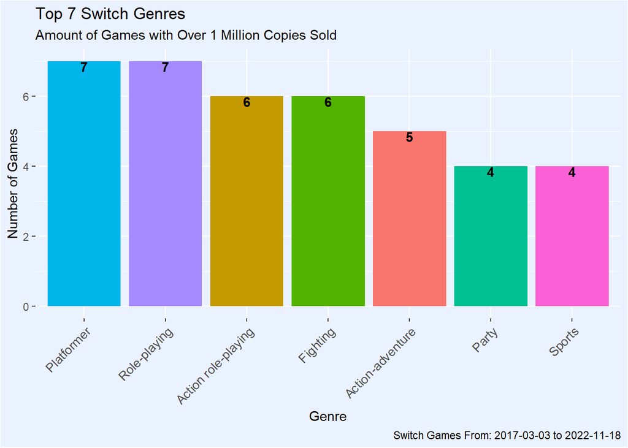

- The graph showcases that **platformers** and **role-playing games** are the Switch’s most popular genres.

### Code

```
min_date = min(switch_sales$release_date)
max_date = max(switch_sales$release_date)


ggplot(data = top_genres, aes(x  =reorder(Genre,-count), y = count)) +
  geom_bar(stat= 'identity',mapping = aes(fill= Genre)) +
  labs(title = 'Top 7 Switch Genres', subtitle = 'Amount of Games with Over 1 Million Copies Sold',
       y = "Number of Games",
       x = "Genre",
       caption = paste0("Switch Games From: ", min_date, " to ", max_date)) +
  theme(axis.text.x = element_text(size = 10, angle = 45, hjust = 1),
        legend.position = 'None',
        panel.background = element_rect(fill="#ebf2ff"),
        legend.background = element_rect(fill="#ebf2ff"),
        plot.background = element_rect(fill="#ebf2ff")) +
  geom_text(aes(label = count, fontface= 'bold'),vjust = 1)
```

## Switch Games Split By Year

Note: This graph will showcase the amount of titles per year that have sold at least 1 million copies.

### Pie Chart

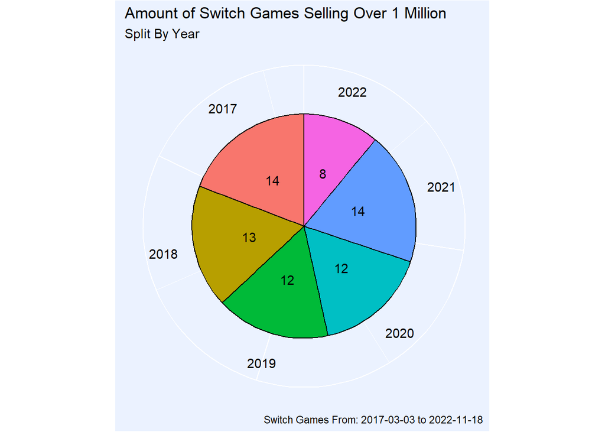

### Code

```
# Year Pie Chart

ggplot(data = grouped_year,aes(x = "",y = num_of_titles, fill = year)) +
  geom_bar(stat = 'identity', color = 'black') +
  geom_text(aes(x = 1.7,label = year),
            position = position_stack(vjust = 0.5)) +
  geom_text(aes(label = num_of_titles),
            position = position_stack(vjust = 0.5)) +
  coord_polar(theta = 'y') +
  theme(axis.title = element_blank(),
        axis.text = element_blank(),
        axis.ticks = element_blank(),
        legend.position= 'None',
        panel.background = element_rect(fill=("#ebf2ff")),
        legend.background = element_rect(fill="#ebf2ff"),
        plot.background = element_rect(fill="#ebf2ff"),
        plot.caption.position = 'plot') +
  labs(title = "Amount of Switch Games Selling Over 1 Million", subtitle='Split By Year',
       caption = paste0("Switch Games From: ", min_date, " to ", max_date))
```

As a result, the Nintendo Switch is actually fairly consistent in the quantity of games achieving that milestone.

- However, 2022 is the exception with only 8 games

Even though 2022 contained less games selling over 1 million copies, those 8 games might have sold more individually than titles from previous years.

**DATA SET LIMITATIONS**

- Not including Black Friday 2022 or Christmas 2022, the data will be skewed against that year
  - Key moments where more games could have reached over 1 Million copies sold

## Switch Yearly Performance

Note: This graph will investigate the sales within each year. However, like the chart prior, the limitations of the data will affect the results.

- Data is limited to games selling over 1 million copies
  - Missing hundreds of games that sold less.
- Unclear whether 2022 has actually sold as poorly as it did.

Yet, understanding a franchise’s contribution towards the Switch’s yearly sales can provide insight on the console’s overall success.

### Bar Chart

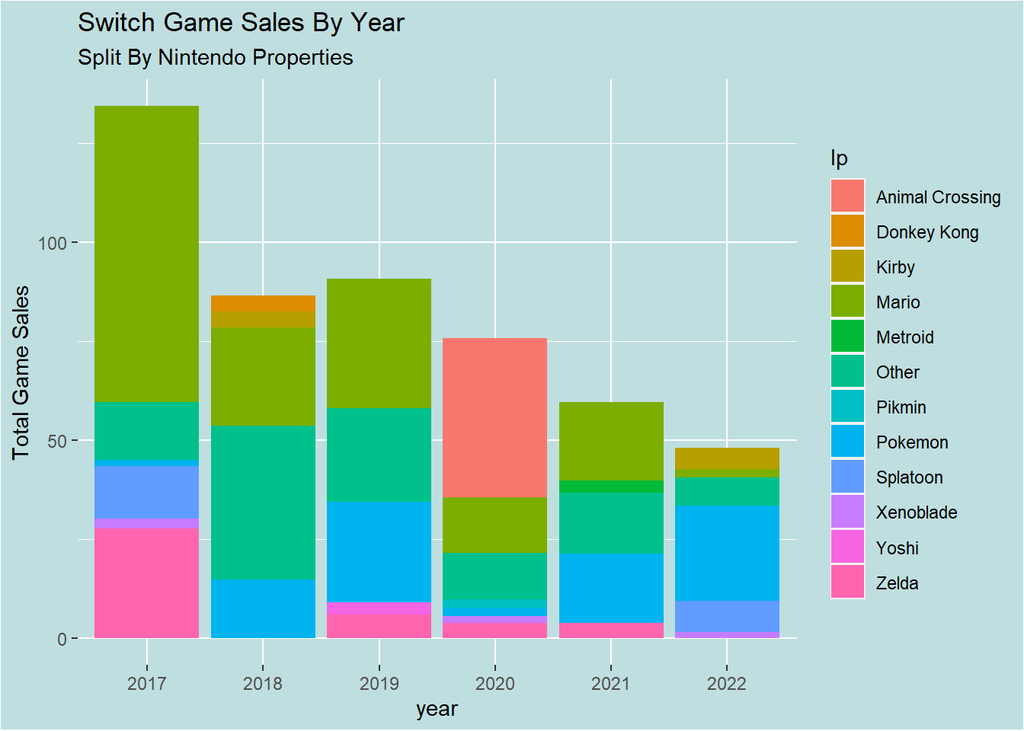

### Code

```
grouped_year_ip <- year_added %>%
  group_by(year,Ip) %>%
  summarize(Units_Sold_Year = sum(Units_Sold_Mill), Avg_Sales = mean(Units_Sold_Mill))

# Stacked Bar Graph

ggplot(data = grouped_year_ip, aes(x = year, y = Units_Sold_Year)) +
  geom_bar(stat = 'identity', aes(fill = Ip)) +
  labs(title = "Switch Game Sales By Year",
       subtitle = "Split By Nintendo Properties",
       y = "Total Game Sales") +
  theme(panel.background = element_rect(fill ='#BFDEDF',),
        legend.background = element_rect(fill ='#BFDEDF'),
        plot.background = element_rect(fill ='#BFDEDF'))
```

However, this doesn’t mean that the Switch is performing poorly.

- 2022 sold at least 40 million copies
- Only 8 titles in the data set
- Excluding 2022’s holiday season

Additionally, the lack of a big Mario title for 2022 has seemingly affected sales.

- *Super Mario Odyssey* in 2017 greatly boosted the sales for that given year

## Franchise Sales

Note: Understanding how each Nintendo property performed in a given year will allow for a better understanding of a year’s total sales.

### Franchise Sales Chart

[figure not shown]

### Code

```
# Line Graph IP's yearly sales

ggplot(data = grouped_year_ip) +
  geom_point(aes(x = year, y = Units_Sold_Year)) +
  geom_line(aes(x = year, y = Units_Sold_Year, group = Ip, color = Ip)) +
  facet_wrap(~Ip,scales = 'free') +
  scale_y_continuous(limits= c(0,75))+
  labs(title = "Yearly Sales For Nintendo Properties",
       subtitle = "2017- 2019",y = "Sales (Millions)") +
  theme(plot.background = element_rect(fill ='#BFDEDF'),
        legend.background = element_rect(fill ='#BFDEDF'),
        legend.position = 'None')
```

As a result, the trends of Nintendo franchises are shown.

For example, Mario’s explosive sales in 2017 was because of the release of *Super Mario Odyssey* (~24 Million), *Mario Kart 8 Deluxe* (~48 Million), and *Mario + Rabbids Kingdom Battle* (~2 Million). Meanwhile, in 2022 there was only *Mario Strikers: Battle League* (~2 Million).

- Explosive popularity may stem from the pandemic
- Greater Switch sales when people were quarantined

Lastly, Pokemon in 2017 saw smaller sales

- 2017 only saw the release of the spin-off title *Pokken Tournament DX* (~1.5 Million)

Meanwhile, the series saw spikes in sales whenever mainline titles released, such as:

- *Pokemon Sword and Shield* (~25 Million) in 2019
- *Pokemon Brilliant Diamond and Shining Pearl* (~15 Million) in 2021
- *Pokemon Legends: Arceus* and *Pokemon Scarlet and Violet* in 2022.

Therefore, these sale figures help highlight the importance of Nintendo IPs towards the Switch’s performance for a given year.

However, how does the Switch compare to other consoles?

# Tableau Dashboard For Console Statistics

Note: The following dashboard uses data obtained from [Kaggle](https://www.kaggle.com/datasets/gregorut/videogamesales)

[figure not shown]

There are key takeaways from this dashboard:

## Top Selling Games

Firstly, the top 10 selling games for each console help indicate the console’s success.

- The Wii’s bestselling game *Wii Sports* (~82 Million) has sold more units than the top 10 games of the WiiU combined.
- Highlighting the Wii’s astronomical success and WiiU’s failure

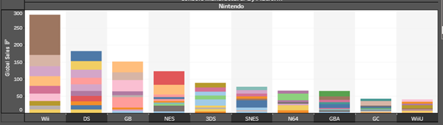

When comparing Nintendo’s home consoles with Sony’s:

- Sony’s home consoles’ top 10 games combined sales are greater
  - The Wii and NES are exceptions
- Nintendo completely dominates the handheld market.

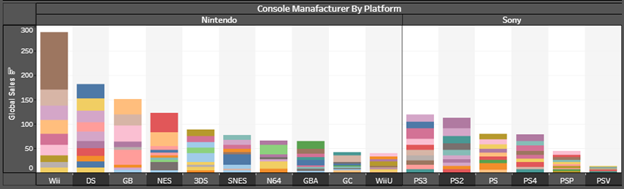

When investigating the top 10 games for Nintendo consoles, the franchises represented are usually Nintendo’s major IPs.

- *Mario* contains three titles in the top 10 games for the Wii:
  1. *Mario Kart Wii* (~35 Million Sales, Ranking #2)
  2. *New Super Mario Bros. Wii* (~28.62 Million Sales, Ranking #5)
  3. *Super Mario Galaxy* (~11.52 Million Sales, Ranking #9).

Even Nintendo’s weaker-selling consoles share this behavior.

- The Nintendo GameCube’s top-selling games include:
  1. *Mario Kart: Double Dash!!* (~6.95 Million Sales, Ranking #2)
  2. *Super Mario Sunshine* (~6.31 Million Sales, Ranking #3)
  3. *Luigi’s Mansion* (~3.6 Million Sales, Ranking #5)

This is *similar* behavior to the Nintendo Switch

- Nintendo’s franchises garner the largest sales for the console

## Yearly Sales

The Nintendo Switch saw a consistent quantity of games reaching the 1 Million benchmark from 2017-2021.

Therefore, it is important to see how Nintendo’s other home consoles perform across their lifespan.

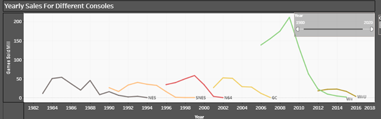

The chart indicates a similar behavior across all platforms.

- Each of the consoles experiences an overall **increase** in sales for the **first few years**
- Experiences a **decrease** in sales over time.

The console with the biggest dip is the Nintendo Wii:

### Wii’s Starting Sales

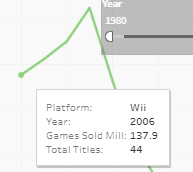

### Wii’s Drop in Sales

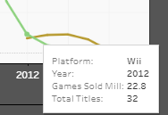

- Wii saw over 100 million sales in 2006
- 22 Million sales in 2012

**Similar** behavior can be seen across competitive console manufacturers:

### Microsoft Sales

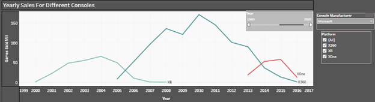

### Sony Sales

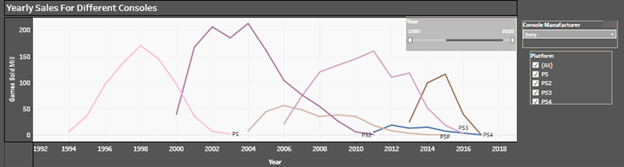

### Sega Sales

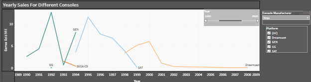

Note: Consoles experience the biggest dip in sales when a new console has arrived in the market.

- However, have already experienced their peak in sales years before the next console’s release.

## Genre

Lastly, different console manufacturers experience greater sales depending on the genre.

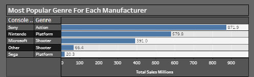

Nintendo consoles have greater sales when the genre is a *platformer*.

- This correlates to the Wii’s and Switch’s top-selling games including *Mario*

On the other hand, Sony’s action games sell extraordinarily well, while Microsoft’s shooters are the biggest genre for their platform.

A possible explanation is the consumer’s perception of these platforms.

- Customers purchase a Nintendo console with the intent to play platformers
- A Sony console owner intend to play Sony’s action games.

### Platformer Sales

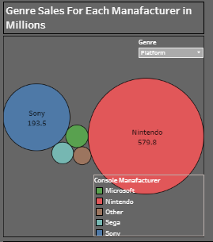

### Action Sales

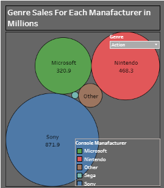

### Shooter Sales

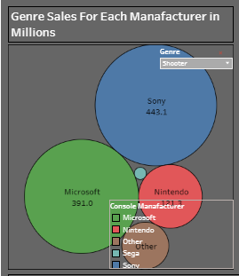

## Conclusion

The data from Kaggle for different consoles highlighted behavioral trends.

- Nintendo consoles, the Switch included, are favorable towards platformers
- Other competitors have different genres where the sales are highest
- Nintendo properties, like *Mario* and *Pokémon* perform well.
- Consoles tend to rise in sales for a few years, but then see a dip.
  - Most notably when a new console is released.

With this analysis, consumers would be able to understand what genres and franchises are most prominent when purchasing a Nintendo Switch. In addition, highlighting the behavior trends across all Nintendo platforms provides foresight for Nintendo’s next console.

However, the limitation of the data means further analysis is required.

Limitations:

- The lack of 2022 Holiday Sales
- Switch games selling under 1 Million copies
- 2023 sales

Further analysis may provide better insight on sales trends for the Nintendo Switch and the customer’s perception of these companies.